# Gesamtauswertung der Zyklen 1-6 der Legierung LEK94

Stephan Rietzler

# Auswertung

## Viscosity

### Graphische Analyse

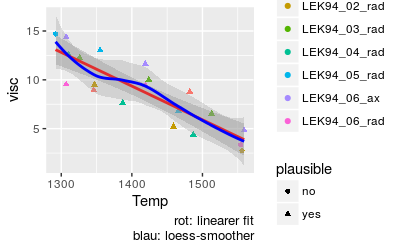

```r
visc %>%
  ggplot(aes(x=Temp, y=visc)) +
  geom_point(aes(color=data, shape=plausible)) +
  stat_smooth(method="lm", col="red") +
  stat_smooth(col="blue", alpha=0.3) +
  labs(
    caption="rot: linearer fit\nblau: loess-smoother"
  )
```

```r
#ggplotly(visc_plot)
```

**Folgerung:**

- Keine Daten fallen extrem auf.
- Der loess-smoother weicht nicht auffällig vom linearen Fit ab, was als Indiz aufgefasst wird das der Zusammenhang zwischen Viskosität und Temperatur linear ist.
- Die Viskositäts-Wert die per Konvention als nicht plausibel gelten (d.h. diejenigen bei denen das Intervall viskosität $\pm 3\cdot sd$ die Null enthält) liegen alle am ‘Rand’ des Auswertungsbereichs. Im Regelfall sind dort weniger Daten zur Schätzung der Dämfungs-Konstanten vorhanden und deswegen sind die Schätzungen dort tendenziell unsicher.

### Numerische Analyse

Analyse mit allen Daten, die als plausibel definiert wurden. D.h. die drei Viskositäts-Werte am Rand des Temperaturbereiches die in obigem Plot als Kreise eingezeichnet sind werden ausgenommen.

Die Daten werden so umskaliert, das der Temperatur-Nullpunkt der Schmelztemperatur von LEK94 (1393°C) entspricht. Die bei ‘Intercept’ angegebene Größe entspricht damit der Viskosität am Schmelzpunkt.

```r
(visc_lm <- lm(visc ~ I(Temp-1393), data=visc %>% filter(plausible=="yes")) %>% summary())
```

```
Call:
lm(formula = visc ~ I(Temp - 1393), data = visc %>% filter(plausible ==
    "yes"))

Residuals:
    Min      1Q  Median      3Q     Max
-2.5866 -2.0265  0.5414  1.3739  2.8451

Coefficients:
                Estimate Std. Error t value Pr(>|t|)
(Intercept)     9.558320   0.469500  20.358 2.44e-12 ***
I(Temp - 1393) -0.029748   0.006041  -4.924 0.000183 ***
---
Signif. codes:  0 ‘***’ 0.001 ‘**’ 0.01 ‘*’ 0.05 ‘.’ 0.1 ‘ ’ 1

Residual standard error: 1.906 on 15 degrees of freedom
Multiple R-squared:  0.6178,    Adjusted R-squared:  0.5923
F-statistic: 24.25 on 1 and 15 DF,  p-value: 0.0001834
```

# Surface-Tension

## Graphische Analyse

Zunächst werden alle im Vorfeld als auswertbar gewertete Datensätze dargestellt:

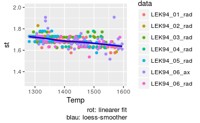

```r
st  %>%
  ggplot(aes(x=Temp, y = st)) +
  geom_jitter(aes(color=data)) +
  stat_smooth(method="lm", col="red") +
  stat_smooth(col="blue") +
  labs(
    caption="rot: linearer fit\nblau: loess-smoother"
  ) + ylim(c(1.3,2))
```

**Folgerung:**  
Hier sieht man das die Daten des Datensatzes LEk94_06_ax im Randbereich auffällig aus der Datenwolke herausfallen. Da dieser Datensatz eher zur Illustration der Möglichkeit der Datenselektion durch das Auswerteprogramm ‘Levitator’ in die Gesamtauswertung aufgenommen wurde (siehe Kommentar im Anhang) wird er jetzt aufgrund dieser Auffälligkeiten wieder ausgeschlossen.

Im nachfolgenden Plot sind die Daten des Datensatzes LEK94_06_ax ausgenommen:

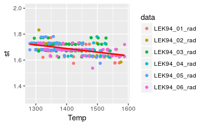

```r
st %>% filter(data != 'LEK94_06_ax') %>%
  ggplot(aes(x=Temp, y = st)) +
  geom_jitter(aes(color=data)) +
  stat_smooth(method="lm", col="red") +
  ylim(c(1.3,2))
```

In diesem Plot sind nun keine offensichtlichen Ausreißer mehr zu finden. Die folgende numerische Analyse wird nur mit den sechs Datensätzen der Radial-Kamera durchgeführt.

## Numerische Analyse

```r
lm(st ~ I(Temp - 1393), data=st %>% filter(data != 'LEK94_06_ax')) %>% summary()
lm(st ~ I(Temp - 1393) + I((Temp - 1393)^2), data=st %>% filter(data != 'LEK94_06_ax')) %>% summary()
```

[output not shown]

# Anhang: Summary der verwendeten Datensätze

**In dem Kommentare zu dem Datensatz der Axial-Kamera des Zyklus 6 habe ich einige generelle Bemerkungen gemacht und exemplarisch auch Möglichkeiten des Programms aufgezeigt einzelne Datenpunkte bzw. Zeitspannen aus der Auswertung auszunehmen.**

## Summary for LEK94_01_rad

*Sample-Specification:* - Alloy: LEK94 - m: 1.1984g - radius: 3.3678mm - Melt.-Temp: 1393.0°C

*Experimental Design: (times are in seconds from start of recording)* - Max. measured Temp. of alloy: 1600.0°C - End of Heatphase to time of solidification: (0.0, 16.2765) - Data-Evaluation-Range: (0.0, 14.0) - Temp-Span: (1600.0, 1275.0) - Heat-pulse-Times at: 2.0/7.0 - Temp. at Heat-Pulse-Times: 1540.0/1434.0

*Evaluation Parameters:* - Set Bandpass: Low: 10.0Hz, High: 200.0Hz - Set smoothing of spectrogramm: smooth = 2, i.e. running mean over 5 adjacent periodogram ordinates - Set amplitude-fraction: 95.0% - Set time-window-size: 1.0s - Set time-window-overlap: 50.0% - Variables used for evaluation: R_RadiusX, R_RadiusY - Time-Intervalls excluded from evaluation:

**Remarks:**

Auswertezeit: - bis 14s da ab dann signal/noise-ratio zu schlecht, wie man an den signal-plots und dem spektrogram erkennen kann

Spektrogramm: - Oberschwingungen schwach erkennbar

Viscosity: Viscosity-Value im ersten Auswertesegment nicht ermittelbar, da nur daten für zwei verschiedene Zeitpunkte vorhanden; Der erste Heipuls kommt für eine Auswertung also zu früh.

## Summary for LEK94_02_rad

*Sample-Specification:* - Alloy: LEK94 - m: 1.1984g - radius: 3.3678mm - Melt.-Temp: 1393.0°C

*Experimental Design: (times are in seconds from start of recording)* - Max. measured Temp. of alloy: 1605.0°C - End of Heatphase to time of solidification: (0, 15.1172) - Data-Evaluation-Range: (0.0, 15.1172) - Temp-Span: (1605.0, 1295.0) - Heat-pulse-Times at: 3/8 - Temp. at Heat-Pulse-Times: 1516.0/1413.0

*Evaluation Parameters:* - Set Bandpass: Low: 10.0Hz, High: 200.0Hz - Set smoothing of spectrogramm: smooth = 2, i.e. running mean over 5 adjacent periodogram ordinates - Set amplitude-fraction: 95.0% - Set time-window-size: 1.0s - Set time-window-overlap: 50.0% - Variables used for evaluation: R_RadiusX, R_RadiusY - Time-Intervalls excluded from evaluation:

**Remarks:**

Signalqualität und Signal-Rausch-Verhältnis lassen eine Auswertung bis zur Erstarrung zu.

Im Spektrogramm sind Oberschwingungen bis zur Ordnung 2 deutlich erkennbar. Bei R_RadiusY legen Signal-Plot und Spektrogramm eine Modulation kurz nach Ende der Heizphase nahe. Diese klingt jedoch schnell ab.

ST: - keine besonderen auffälligkeiten; plausible werte

## Summary for LEK94_03_rad

*Sample-Specification:* - Alloy: LEK94 - m: 1.1984g - radius: 3.3678mm - Melt.-Temp: 1393.0°C

*Experimental Design: (times are in seconds from start of recording)* - Max. measured Temp. of alloy: 1566.0°C - End of Heatphase to time of solidification: (0, 15.5752) - Data-Evaluation-Range: (0.0, 15.0) - Temp-Span: (1566.0, 1272.0) - Heat-pulse-Times at: 4.0/8.0 - Temp. at Heat-Pulse-Times: 1470.0/1387.0

*Evaluation Parameters:* - Set Bandpass: Low: 3.0Hz, High: 200.0Hz - Set smoothing of spectrogramm: smooth = 2, i.e. running mean over 5 adjacent periodogram ordinates - Set amplitude-fraction: 95.0% - Set time-window-size: 1.0s - Set time-window-overlap: 50.0% - Variables used for evaluation: R_RadiusX, R_RadiusY - Time-Intervalls excluded from evaluation:

**Remarks:**

Auswertzeit: bis 15s nach ende der Heizphase,d ann sig/noise zu klein, was man vor allem daran erkennt das die dominante Frequenz zu springen anfängt.

Spektrogramm: Oberschwingungen deutlich erkennbar; Nach Ende der Heizphase ist sowohl im signal als auch spectrogramm eine Signal-Modulation zu erkennen, die jedoch bald abklingt.

st: keine auffälligkeiten; plausible und konsistente werte

visc: keine auffälligkeiten; plausible und konsitente werte

Bemerkung: Was man hier sehr schön sieht ist wie die Heizpulse den gesamten Tropfen im Versuchsaufbau (bei einer freq. von 6 Hz) zum schwingen anregen: Betrachte hierzu das signal R_CenterY mit einem BP von 3-30Hz.

## Summary for LEK94_04_rad

*Sample-Specification:* - Alloy: None - m: 1.1984g - radius: 3.3678mm - Melt.-Temp: 1393°C

*Experimental Design: (times are in seconds from start of recording)* - Max. measured Temp. of alloy: 1561.0°C - End of Heatphase to time of solidification: (0, 15.6495) - Data-Evaluation-Range: (0.0, 15.0) - Temp-Span: (1561.0, 1273.0) - Heat-pulse-Times at: 6.0/10.0 - Temp. at Heat-Pulse-Times: 1426.0/1353.0

*Evaluation Parameters:* - Set Bandpass: Low: 5.0Hz, High: 200.0Hz - Set smoothing of spectrogramm: smooth = 2, i.e. running mean over 5 adjacent periodogram ordinates - Set amplitude-fraction: 95.0% - Set time-window-size: 1.0s - Set time-window-overlap: 50.0% - Variables used for evaluation: R_RadiusX, R_RadiusY - Time-Intervalls excluded from evaluation:

**Remarks:**

Direkt nach Ende der Heizphase sind die Signale noch sehr ‘unruhig’. Eine Modulation ist nicht direkt erkennbar. Evtl. ist direkt nach Ende der Heizphase mit einem starken multiplikativen (niederfrequentem) Rauschen zu rechnen. Dieser Effekt ist immer wieder beobachtbar.

Ein möglicher Grund liegt evtl. in der Signalgenerierung durch die Tevi-Software: Direkt nach der Heizphase oszilliert der Tropfen noch sehr stark im Versuchsaufbau und läuft deswegen häufig in die Bildbegrenzung. Dadurch steigt der Kanten-Erkennungs und Ellipsen-Fit-Algorithmus von Tevi aus und liefert dann verrauschte Signale. Dies ist deutlich in den Filmen zu sehen. Dies wäre eine Erklärung für das beobachtete niederfrequente mulitplikative Rauschen: Bei großen Signal-Amplituden springt das Signal stärker als bei kleinen.

Ausgewertet wird das Signal bis 15s (danach schlechtes signal/rausch-verhältnis) mit einem Hochpass ab 5Hz um das niederfrequente Rauschen zu unterdrücken.

## Summary for LEK94_05_rad

*Sample-Specification:* - Alloy: LEK94 - m: 1.1984g - radius: 3.3678mm - Melt.-Temp: 1393°C

*Experimental Design: (times are in seconds from start of recording)* - Max. measured Temp. of alloy: 1534.0°C - End of Heatphase to time of solidification: (0.0, 14.587) - Data-Evaluation-Range: (0.0, 14.587) - Temp-Span: (1534.0, 1273.0) - Heat-pulse-Times at: 6.0/12.0 - Temp. at Heat-Pulse-Times: 1411.0/1312.0

*Evaluation Parameters:* - Set Bandpass: Low: 5.0Hz, High: 200.0Hz - Set smoothing of spectrogramm: smooth = 2, i.e. running mean over 5 adjacent periodogram ordinates - Set amplitude-fraction: 95.0% - Set time-window-size: 1.0s - Set time-window-overlap: 50.0% - Variables used for evaluation: R_RadiusX, R_RadiusY - Time-Intervalls excluded from evaluation:

**Remarks:**

Gute Signalqualität die eine Auswertung über den gesamten aufgezeichneten Zeitraum zulässt. Um die omnipräsente niederfrequente Schwingung herauszufiltern wird ein 5Hz high-pass gesetzt (fast schon default).

spectrogramm: oberschwingungen deutlich erkennbar; im ersten auswertesegement lassen sich modulationen der dominanten schwingung bei ca. 35 Hz erahnen; dies wird durch die signalplots gestützt.

visc: das letzte auswerte segment ist zu kurz für eine sichere Auswertung der dämpfungskonstante, was sich in einer hohen sd niederschlägt.

## Summary for LEK94_06_rad

*Sample-Specification:* - Alloy: LEK94 - m: 1.1984g - radius: 3.3678mm - Melt.-Temp: 1393°C

*Experimental Design: (times are in seconds from start of recording)* - Max. measured Temp. of alloy: 1618.0°C - End of Heatphase to time of solidification: (0, 17.6158) - Data-Evaluation-Range: (0.0, 15.5) - Temp-Span: (1618.0, 1266.0) - Heat-pulse-Times at: 4.0/11.0 - Temp. at Heat-Pulse-Times: 1498.0/1355.0

*Evaluation Parameters:* - Set Bandpass: Low: 7.0Hz, High: 200.0Hz - Set smoothing of spectrogramm: smooth = 2, i.e. running mean over 5 adjacent periodogram ordinates - Set amplitude-fraction: 95.0% - Set time-window-size: 1.0s - Set time-window-overlap: 50.0% - Variables used for evaluation: R_RadiusX, R_RadiusY - Time-Intervalls excluded from evaluation:

**Remarks:**

Auswertsignale: radius x and y

Auswertzeit: nur bis 15.5s da aufnahme kein signal

Bandpass: hp ab 7hz; da sonst bei ca. 10s aufgrund des schlechten sig/noise ratio dominante freq auftauchen die nicht ins bild passen

Spektrogramm: zeigt keine Auffälligkeiten; Oberschwingeungen bis Ordnung 2/3 sind erkennbar

Results Surface-Tension: keine auffälligkeiten

Visc: keine auffälligkeiten

## Summary for LEK94_06_ax

*Sample-Specification:* - Alloy: LEK94 - m: 1.1984g - radius: 3.3678mm - Melt.-Temp: 1393°C

*Experimental Design: (times are in seconds from start of recording)* - Max. measured Temp. of alloy: 1627.0°C - End of Heatphase to time of solidification: (0.0, 18.0667) - Data-Evaluation-Range: (0.0, 16.0) - Temp-Span: (1627.0, 1265.0) - Heat-pulse-Times at: 5/12 - Temp. at Heat-Pulse-Times: 1498.0/1355.0

*Evaluation Parameters:* - Set Bandpass: Low: 5.0Hz, High: 75.0Hz - Set smoothing of spectrogramm: smooth = 2, i.e. running mean over 5 adjacent periodogram ordinates - Set amplitude-fraction: 95.0% - Set time-window-size: 1.0s - Set time-window-overlap: 50.0% - Variables used for evaluation: A_RadiusX, A_RadiusY - Time-Intervalls excluded from evaluation: (8.8,9.8),(9.7,10.7),(10.6,11.6)

**Remarks:**

Wie alle Datensätze der Axial-Kamera ist auch dieser von sehr schlechter Qualität. Insbesondere im Bereich um 10s kurz vor dem zweiten Heizpuls ist das Signal von andauerndem starkem niederfrequenten additivem Rauschen überlagert.

Dieses Rauschen ist deutlich am ‘Springen’ der Frequenz in diesem Bereich zu erkennen. Siehe Signal-Plot (Display ‘results’) und Ergebnisse Surface-Tension.

In den Ergebnissen ‘Viskosität’ führt dieses Rauschen sogar zu einer ‘negativen’ Dämpfung, verursacht durch die dominaten niederfrequenten Störungen mit in diesem Bereich ‘anwachsender Amplitude’.

Mehr aus Gründen der Illustration der Programmmöglichkeiten habe ich mich entschlossen diesen Datensatz nicht komplett auszunehmen sondern nur den Bereich um ca. 10s. Hierzu selektiert man mit der Option ‘Data-Selection’ Zeitpunkte in diesem Bereich, welcher dann ausgenommen wird.

Die so erhaltenen Ergebnisse für die Surface-Tension und die Viskosität passen dann in das Gesamtbild der ersten sechs Zyklen der Legierung LEK94.

**Generelle Bemerkung zu den Datensätzen:** Es fällt auf das wenn das Signal RadiuxX schlecht ist dann ist auch das Signal RadiusY schlecht. Das ist verständlich, da beide aufgrund ihrer Konstruktion korreliert sind. Man sollte sich also immer bewußt sein das diese beiden Signale keine unabhängigen Informationen liefern.

In unterschiedlichem (nicht genau bekanntem) Ausmaß gilt dies für alle vorhandenen Signale. Verwendet man zwei oder mehr der vorhandenen Signale zur Schätzung der Dämpfung oder Frequenz des Signales zu einem Zeitpunkt so ist dies strenggenommen eine Datenvervielfachung die dann den Standardfehler reduziert. Aus dieser Perspektive betrachtet ist der angegebenen Standardfehler also systematisch zu klein falls man mehrere Signale verwendet. Ich habe mich entschieden default-mäßig immer zwei Signale zu verwenden, nämlich RadiusX und RadiusY. Primär aus Gründen der *Auswerte-Effizienz*: Die mühevolle, zeitaufwendige und immer **subjektive Auswahl der ‘besten’ Signale** ist im Effekt auf die Qualität der Ergebnisse schwer abzuschätzen.

Report generated on Sun Aug 13 12:27:31 2017

# Rohdaten

## Viskosität

```r
visc_raw %>% print(dim(visc_raw)[1])
```

[output not shown]

## Surface-Tension

```r
st_raw %>% print(dim(st_raw)[1])
```

[output not shown]